# M2 - Eksamen

Shabana, Las, Andreas

24 10 2019

```r
knitr::opts_chunk$set(warning=FALSE,
                     message=FALSE,
                     fig.align="center"
                     )
options(warn=-1) # Hides all warnings, as the knitr options only work on local R-Markdown mode.
Sys.setenv(LANG = "en")
```

```r
library(pacman)
library(tidyverse)
library(magrittr)
library(SnowballC)
library(corpus)
library(quanteda)
library(tidytext)
library(tm)
library(topicmodels)
library(lsa)
library(uwot) #for UMAP
library(dbscan)# For density based clustering
library(ggraph)
library(igraph)
library(text2vec)
library(randomForest)
library(readr)
library(topicmodels)
library(text2vec)
library(caret)
library(irlba)
library(e1071)
```

# 1 Introduction

In this following assignment we have attempted to make a spam filter for SMS spam. For the purpose of this we are using the NUS SMS corpus of ham and spam messages, the acquisition of which we will discuss later. Our intension is to set up both supervised machine learning models as well as attempting to find patterns in the data using unsupervised learning.

The unsupervised part will contain a topic detection model, followed by a clustering algorithm based on cosine similarity. The supervised part will contain a dimensionality reduction of both a training and testing dataset, as well as several different models for filtering spam messages (decision tree, random Forrest, generalized linear model).

## 1.1 Description of data acquisition

The dataset is a set of SMS labeled messages which is collected for mobile phone spam research. The dataset is a collection of 5.574 real and non-enconded English messages. The dataset is a collection of various free research content on the Internet. For example, some of the spam messages come from a UK forum where you can report if the messages is spam. Additionally, some of ham messages are getting from the Institute of Computer Science at the National University of Singapore. All the messages is incorporated to our dateset " SMS Spam Collection."

## 1.2 Definition of a problem statement and a short outline of the implementation

# 2 Data preparation (general)

We load the majority of the packages needed for the analysis

```r
SMSspam=read_delim("https://raw.githubusercontent.com/apla14/hello-world/master/SpamSms",
    ";",escape_double = FALSE, col_names = FALSE,
    trim_ws = TRUE)
```

Firstly we inspect the data

```r
SMSspam %>% head()
```

| X1 | X2 |
| --- | --- |
| ham | Go until jurong point, crazy.. Available only in bugis n great world la e buffet... Cine there got amore wat... |
| ham | Ok lar... Joking wif u oni... |
| spam | Free entry in 2 a wkly comp to win FA Cup final tkts 21st May 2005. Text FA to 87121 to receive entry question(std txt rate)T&C's apply 08452810075over18's |
| ham | U dun say so early hor... U c already then say... |
| ham | Nah I don't think he goes to usf, he lives around here though |
| spam | FreeMsg Hey there darling it's been 3 week's now and no word back! I'd like some fun you up for it still? Tb ok! XxX std chgs to send, 1.50 to rcv |

We can observe two columns. One indicating whether a SMS is ham(a real legitimate message) or spam(advertising/harassment) and a second column showing the actual text message. These two columns are unnamed in the original dataset, so we add the column names accordingly below.

```r
SMSspam %<>% mutate(ID=rownames(SMSspam)) %>% select(ID,X1,X2)
SMSspam %<>% mutate(ham_spam=X1) %>% mutate(SMS=X2) %>% select(-X1,-X2)
SMSspam %>% head()
```

| ID | ham_spam | SMS |
| --- | --- | --- |
| 1 | ham | Go until jurong point, crazy.. Available only in bugis n great world la e buffet... Cine there got amore wat... |
| 2 | ham | Ok lar... Joking wif u oni... |
| 3 | spam | Free entry in 2 a wkly comp to win FA Cup final tkts 21st May 2005. Text FA to 87121 to receive entry question(std txt rate)T&C's apply 08452810075over18's |
| 4 | ham | U dun say so early hor... U c already then say... |
| 5 | ham | Nah I don't think he goes to usf, he lives around here though |
| 6 | spam | FreeMsg Hey there darling it's been 3 week's now and no word back! I'd like some fun you up for it still? Tb ok! XxX std chgs to send, 1.50 to rcv |

Our next step is to unnest the tokens splitting each SMS up in individual words, then we look at the words used the most in the different texts. We expect to find a large number of words that can be classified as stop words, finding these we remove them and stem the dataset. Then we check for sparcity by removing sparce terms, at differing sparcity levels and we find that we have to accept a very large amount of sparcity which we will handel later, and then we construct a data term matrix.

```r
data = SMSspam %>% unnest_tokens(word,SMS)
data %>% head()
```

| ID | ham_spam | word |
| --- | --- | --- |
| 1 | ham | go |
| 1 | ham | until |
| 1 | ham | jurong |
| 1 | ham | point |
| 1 | ham | crazy |
| 1 | ham | available |

```r
data %>% group_by(word) %>% count() %>% arrange(desc(n)) %>% head()
```

| word | n |
| --- | --- |
| i | 2300 |
| to | 2249 |
| you | 2149 |
| a | 1448 |
| the | 1335 |
| u | 1183 |

```r
own_stopwords = tibble(word = c("gt","lt","ü","2","4"), lexicon="OWN")
data= data %>% anti_join(stop_words%>% bind_rows(own_stopwords),by="word") %>% mutate(word=wordStem(word))
data %>% group_by(word) %>% count() %>% arrange(desc(n)) %>% head()
```

| word | n |
| --- | --- |
| call | 673 |
| ur | 395 |
| free | 282 |
| dai | 261 |
| love | 258 |
| time | 249 |

```r
dtm = data %>%  count(ID, word) %>% cast_dtm(document =ID, term = word, value = n, weighting = tm::weightTf)

dtm
```

```
## <<DocumentTermMatrix (documents: 5455, terms: 7418)>>
## Non-/sparse entries: 35327/40429863
## Sparsity           : 100%
## Maximal term length: 42
## Weighting          : term frequency (tf)
```

```r
dtm %>% removeSparseTerms(sparse = .99)
```

```
## <<DocumentTermMatrix (documents: 5455, terms: 79)>>
## Non-/sparse entries: 8632/422313
## Sparsity           : 98%
## Maximal term length: 8
## Weighting          : term frequency (tf)
```

```r
dtm %>% removeSparseTerms(sparse = .999)
```

```
## <<DocumentTermMatrix (documents: 5455, terms: 1160)>>
## Non-/sparse entries: 25052/6302748
## Sparsity           : 100%
## Maximal term length: 17
## Weighting          : term frequency (tf)
```

```r
dtm %>% removeSparseTerms(sparse = .9999)
```

```
## <<DocumentTermMatrix (documents: 5455, terms: 7418)>>
## Non-/sparse entries: 35327/40429863
## Sparsity           : 100%
## Maximal term length: 42
## Weighting          : term frequency (tf)
```

# 3 NLP

Tf-idf which stands for term-frequency- inverse document frequency, measures how relevant a term is in given document and how often a words appear. The relevans of the word increase to the number of times a word appears, but is offset by the frequency of the word in the corpus.

```r
sms_idf <- data %>%
  count(ham_spam,word, sort = TRUE) %>%
  bind_tf_idf(ham_spam, word, n)

sms_idf %>%
  head()
```

| ham_spam | word | n | tf | idf | tf_idf |
| --- | --- | --- | --- | --- | --- |
| spam | call | 379 | 0.5631501 | 1.1017177 | 0.6204324 |
| ham | call | 294 | 0.4368499 | 0.2615153 | 0.1142430 |
| ham | ur | 251 | 0.6354430 | 0.2615153 | 0.1661781 |
| ham | love | 248 | 0.9612403 | 0.2615153 | 0.2513791 |
| ham | time | 230 | 0.9236948 | 0.2615153 | 0.2415604 |
| ham | dai | 229 | 0.8773946 | 0.2615153 | 0.2294522 |

TF: Term frequency of a word shows how frequently words appear. If the document is long, then it is possible that a word would appear much more times than shorter ones. TF is intended thus: TF(t) = (Number of times term t appears in a document) / (Total number of terms in the document). The figure shows that ‘call’ appears 379 times in spam and 294 times in ham. The term frequency for call is respectively 0.56 and 0.43. IDF: Inverse document frequency shows how common or rare a word is in the document. If IDF is closer to 0, then the word is more common and if not then it will approach to 1. IDF can be calculated: (the total number of documents/number of documents that contain a word and calculating the logarith). When we multiply the numbers for TF and IDF it gives TD-IDF score. If the score is high the more relevant is the word in the document.

```r
sms_idf %>%
arrange(desc(tf_idf))  %>%
head()
```

| ham_spam | word | n | tf | idf | tf_idf |
| --- | --- | --- | --- | --- | --- |
| spam | claim | 115 | 1 | 1.101718 | 1.101718 |
| spam | prize | 94 | 1 | 1.101718 | 1.101718 |
| spam | tone | 85 | 1 | 1.101718 | 1.101718 |
| spam | won | 73 | 1 | 1.101718 | 1.101718 |
| spam | 150p | 71 | 1 | 1.101718 | 1.101718 |
| spam | guarante | 51 | 1 | 1.101718 | 1.101718 |

We use descending order to get the numbers arranged from largest to the smallest numbers. we then construct a data feature matrix, that we promptly makes sparce now the dataset can be used for unsupervised learning.

```r
#document - feature - matrix
sms_dfm <-data %>%
count(ID, word) %>%
cast_dfm(document =ID, term =word, value =n)
sparse = Matrix::Matrix(sms_dfm,sparse = TRUE)

sms_dfm
```

```
## Document-feature matrix of: 5,455 documents, 7,418 features (99.9% sparse).
```

```r
#When the document-feature-matrix is created, we execute a LDA with the quanteda function textmodel_lsa():
sms_lsa <-sms_dfm %>%
textmodel_lsa(nd =5)
sms_lsa %>% glimpse()
```

```
## List of 5
##  $ sk             : num [1:5] 34.2 28.1 23.7 22.8 20
##  $ docs           : num [1:5455, 1:5] -1.21e-03 -5.87e-02 -1.45e-04 -1.62e-02 -7.88e-05 ...
##   ..- attr(*, "dimnames")=List of 2
##   .. ..$ : chr [1:5455] "1" "10" "100" "1000" ...
##   .. ..$ : NULL
##  $ features       : num [1:7418, 1:5] -3.53e-05 -4.50e-05 -7.28e-04 -4.96e-04 -4.52e-03 ...
##   ..- attr(*, "dimnames")=List of 2
##   .. ..$ : chr [1:7418] "amor" "buffet" "bugi" "cine" ...
##   .. ..$ : NULL
##  $ matrix_low_rank: num [1:5455, 1:7418] 2.47e-05 -1.47e-04 1.42e-06 1.69e-04 1.13e-06 ...
##   ..- attr(*, "dimnames")=List of 2
##   .. ..$ : chr [1:5455] "1" "10" "100" "1000" ...
##   .. ..$ : chr [1:7418] "amor" "buffet" "bugi" "cine" ...
##  $ data           :Formal class 'dgCMatrix' [package "Matrix"] with 6 slots
##   .. ..@ i       : int [1:35327] 0 0 3162 0 383 715 1141 1842 2674 4413 ...
##   .. ..@ p       : int [1:7419] 0 1 3 10 17 31 32 39 140 175 ...
##   .. ..@ Dim     : int [1:2] 5455 7418
##   .. ..@ Dimnames:List of 2
##   .. ..@ x       : num [1:35327] 1 1 1 1 1 1 1 1 1 1 ...
##   .. ..@ factors : list()
##  - attr(*, "class")= chr "textmodel_lsa"
```

```r
sms_lsa_loading <-sms_lsa$docs %>%as.data.frame() %>%rownames_to_column(var ="ID") %>%as_tibble()
sms_lsa_loading %>%head()
```

| ID | V1 | V2 | V3 | V4 | V5 |
| --- | --- | --- | --- | --- | --- |
| 1 | -1.207425e-03 | -2.171016e-03 | 2.216910e-03 | 0.0004760766 | -0.0036618635 |
| 10 | -5.866009e-02 | 1.685038e-02 | -4.964125e-02 | -0.0405153531 | 0.0140743337 |
| 100 | -1.453913e-04 | -6.074401e-05 | -4.964589e-05 | -0.0003372759 | -0.0003768229 |
| 1000 | -1.619958e-02 | -3.201875e-02 | 5.663630e-03 | 0.0131129482 | -0.0167260636 |
| 1001 | -7.884458e-05 | -2.349506e-05 | -5.125672e-05 | -0.0002217190 | -0.0003295467 |
| 1002 | -3.108168e-04 | -3.905122e-04 | 2.795814e-04 | 0.0001676521 | -0.0007104117 |

# 4 Unsupervised ML

## 4.1 LDA

With a dataset now ready to use we now want find out if we can identify topics in the dataset, we will be looking for 2 topics as we want to identify ham and spam separately.

```r
lda = sparse %>%   LDA(k = 2, method = "Gibbs", control = list(seed = 1337))


lda_beta <- lda %>%
  tidy(matrix = "beta") %>%
  group_by(topic) %>%
  arrange(topic, desc(beta)) %>%
  slice(1:10) %>%
  ungroup()

lda_beta %>% head()
```

| topic | term | beta |
| --- | --- | --- |
| 1 | call | 0.034733833 |
| 1 | ur | 0.020388259 |
| 1 | free | 0.014557145 |
| 1 | text | 0.011925403 |
| 1 | send | 0.010635333 |
| 1 | txt | 0.009654881 |

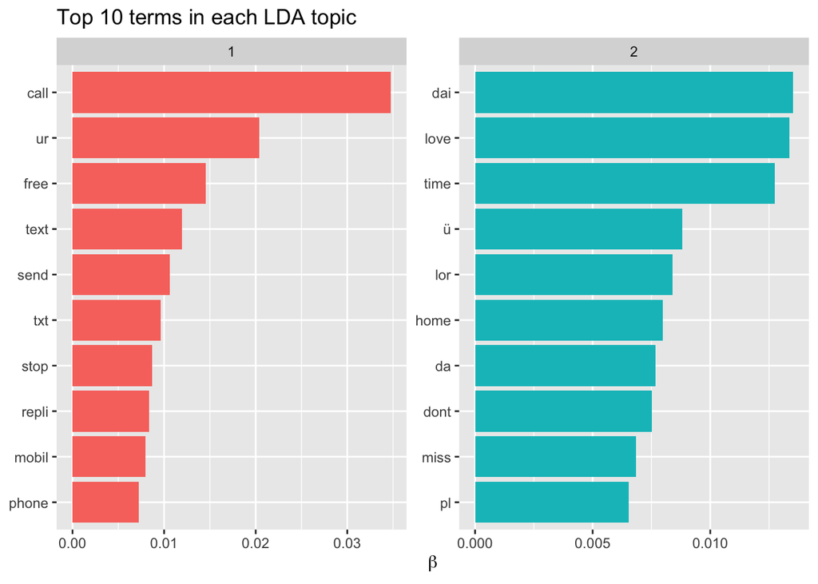

```r
lda_beta %>%
  mutate(term = reorder_within(term, beta, topic)) %>%
  group_by(topic, term) %>%
  arrange(desc(beta)) %>%
  ungroup() %>%
  ggplot(aes(term, beta, fill = as.factor(topic))) +
  geom_col(show.legend = FALSE) +
  coord_flip() +
  scale_x_reordered() +
  labs(title = "Top 10 terms in each LDA topic",
       x = NULL, y = expression(beta)) +
  facet_wrap(~ topic, ncol = 2, scales = "free")
```

Basic topic detection from word choices, we get two figures containing the words that are important for 2 topics. Looking at the left most graph we have words like call free send and several other words that could be connected to spam messages, looking at the right most graph we get words like day, love, time and miss, all words used often in private messages. Using this partition, we then attempt to make a topic distribution the first graph for both topics, then for each topic separately.

```r
lda_gamma <- lda %>%
  tidy(matrix = "gamma")

lda_gamma %>% head()
```

| document | topic | gamma |
| --- | --- | --- |
| 1 | 1 | 0.4745763 |
| 10 | 1 | 0.5937500 |
| 100 | 1 | 0.5283019 |
| 1000 | 1 | 0.4761905 |
| 1001 | 1 | 0.4807692 |
| 1002 | 1 | 0.4905660 |

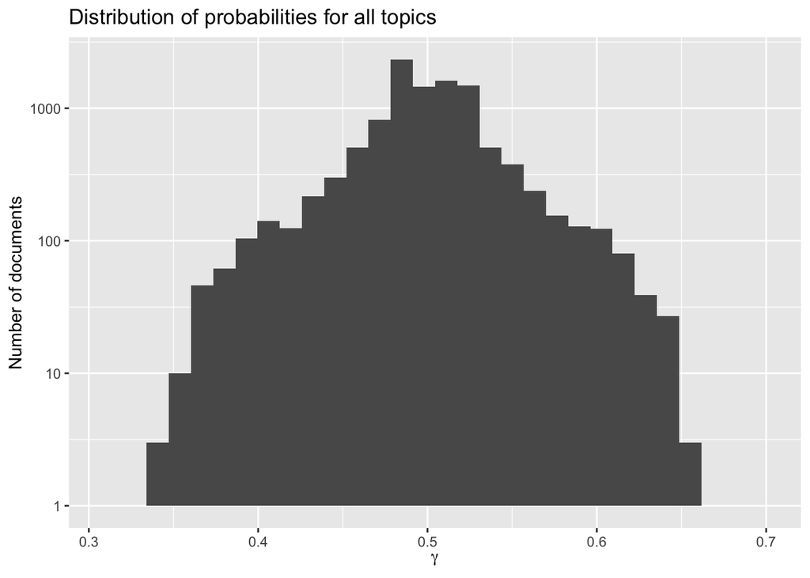

```r
lda_gamma %>%
  ggplot(aes(gamma)) +
  geom_histogram() +
  scale_y_log10() +
  labs(title = "Distribution of probabilities for all topics",
       y = "Number of documents", x = expression(gamma))
```

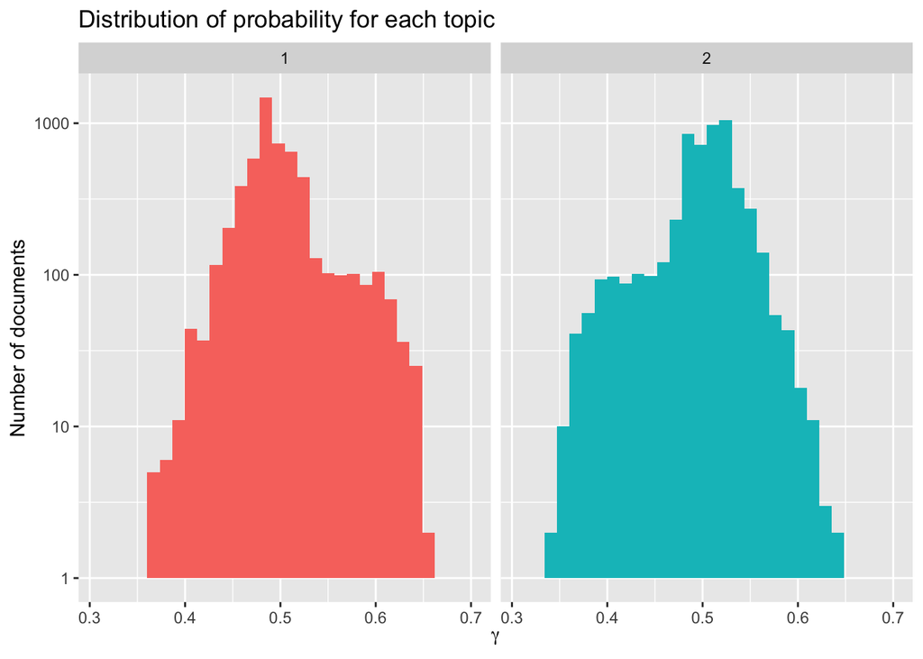

```r
lda_gamma %>%
  ggplot(aes(gamma, fill = as.factor(topic))) +
  geom_histogram(show.legend = FALSE) +
  facet_wrap(~ topic, ncol = 2) +
  scale_y_log10() +
  labs(title = "Distribution of probability for each topic",
       y = "Number of documents", x = expression(gamma))
```

```r
top_topics <- lda %>%
  tidy(matrix = "gamma")  %>%
  group_by(document) %>%
  top_n(1, wt = gamma) %>%
  ungroup()

top_topics %>%
  count(topic)
```

| topic | n |
| --- | --- |
| 1 | 2514 |
| 2 | 3609 |

Looking at the different distributions, we can see that the distribution is relatively tight and in the split topic distribution we see that the documents becomes more and more centralized according to the key terms for the two topics, comparing to the probability distribution of all SMS´s.

## 4.2 Cosine - clustering

Using the umap command we make a dimentionality reduction, and make a n-nearest neighbours lsa model object using the cosine metric. n_neighbors controls how UMAP balances local versus global structure. We use n_neighbors value to be 15, cause small values of n_neighbors to cencentrate on local structure, while large values push UMAP to look at larger neighborhoods.

```r
sms_lsa_umap <- umap(sms_lsa_loading %>% column_to_rownames("ID"),
                       n_neighbors = 15, metric = "cosine", min_dist = 0.01, scale = TRUE,
                       verbose = TRUE, n_threads = 8)
```

The cosine similarity is then plottet in a 2 dimentional graph, and clusters are added using colors with the hbscan command.

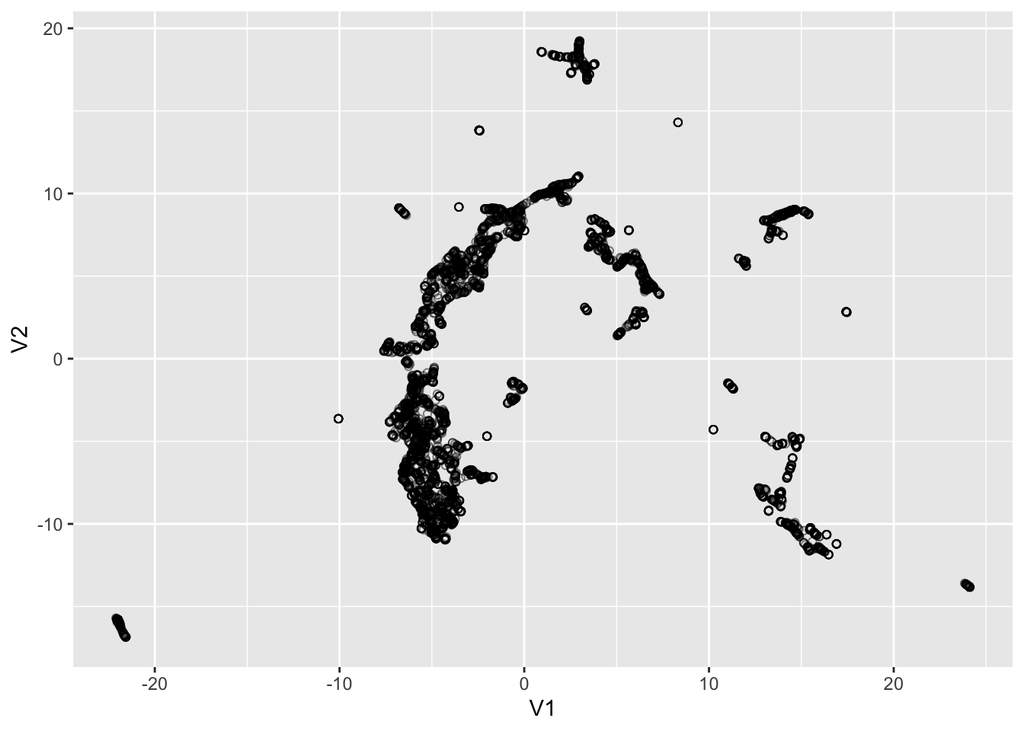

```r
sms_lsa_umap %<>% as.data.frame()
sms_lsa_umap %>%
  ggplot(aes(x = V1, y = V2)) +
  geom_point(shape = 21, alpha = 0.5)
```

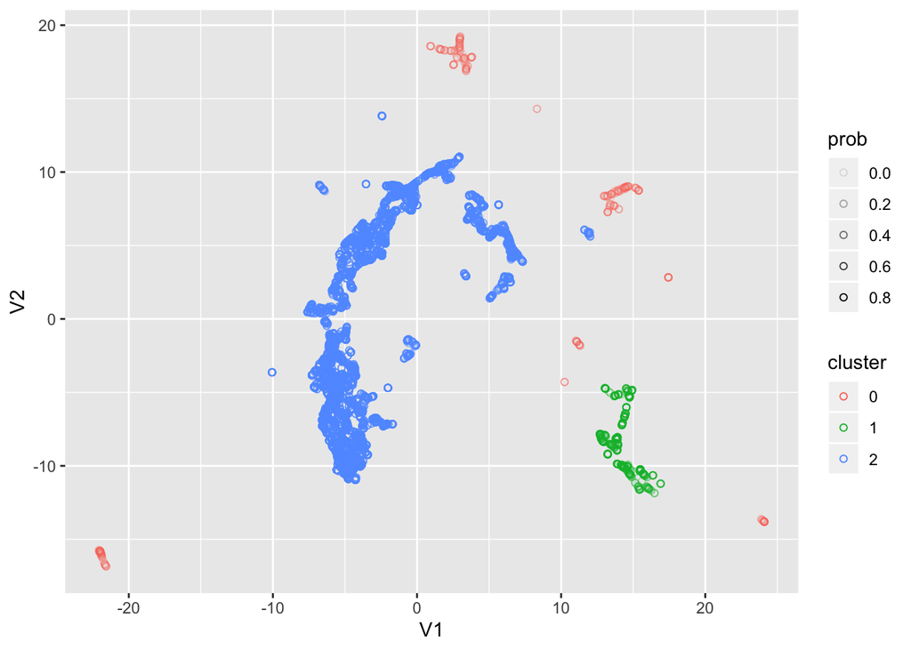

```r
lsa_hdbscan <- sms_lsa_umap %>% as.matrix() %>% hdbscan(minPts = 400)

sms_lsa_umap %>%
  bind_cols(cluster = lsa_hdbscan$cluster %>% as.factor(),
            prob = lsa_hdbscan$membership_prob) %>%
  ggplot(aes(x = V1, y = V2, col = cluster)) +
  geom_point(aes(alpha = prob), shape = 21)
```

Earlier we made a datapreperation for our unsupervised machine learning part, now we are going to make a training and a test set and make a dimentionality reduction. First we will seperate the data using create data partition, and once again we tokenice and remove stopwords, and create a data frequency matrix.

```r
# Use caret to create a 70%/30% stratified split. Set the random
# seed for reproducibility.
set.seed(32984)
indexes <- createDataPartition(as.factor(SMSspam$ham_spam), times = 1,
                               p = 0.7, list = FALSE)

train <- SMSspam[indexes,]
test <- SMSspam[-indexes,]
```

```r
train_tokens = tokens(train$SMS, what = "word",
                remove_numbers = TRUE, remove_punct = TRUE,
                remove_symbols = TRUE, remove_hyphens = TRUE)

train_tokens = tokens_tolower(train_tokens)


train_tokens = tokens_select(train_tokens, stopwords(),
                       selection = "remove")

train_tokens = tokens_wordstem(train_tokens, language = "english")

train_tokens.dfm <- dfm(train_tokens, tolower = FALSE)

train_tokens.matrix <- as.matrix(train_tokens.dfm)

train_tokens.df <- cbind(Label = train$ham_spam, convert(train_tokens.dfm,to = "data.frame"))
```

Next we set up a tfidf workflow and make a dimentionality reduction, saving it as train_svd and add a SpamSimilarity to the reduced dataset making a set ready for making the models.

```r
train_term.frequency <- function(row) {
  row / sum(row)
}


train_inverse.doc.freq <- function(col) {
  corpus.size <- length(col)
  doc.count <- length(which(col > 0))

  log10(corpus.size / doc.count)
}


tf.idf <- function(x, idf) {
  x * idf
}

train_tokens.df <- apply(train_tokens.matrix, 1, train_term.frequency)

train_tokens.idf <- apply(train_tokens.matrix, 2, train_inverse.doc.freq)

train_tokens.tfidf <-  apply(train_tokens.df, 2, tf.idf, idf = train_tokens.idf)

train_tokens.tfidf <- t(train_tokens.tfidf)
```

```r
train_incomplete.cases <- which(!complete.cases(train_tokens.tfidf))
train$SMS[train_incomplete.cases]
```

```
## [1] "What you doing?how are you?" "645"
## [3] ":)"                          ":( but your not here...."
```

```r
train_tokens.tfidf[train_incomplete.cases,] <- rep(0.0, ncol(train_tokens.tfidf))

train_tokens.tfidf.df <- cbind(Label = train$ham_spam, data.frame(train_tokens.tfidf))

train_tokens <- tokens_ngrams(train_tokens, n = 1:2)

train_irlba <- irlba(t(train_tokens.tfidf), nv = 300, maxit = 600)


train_sigma.inverse <- 1 / train_irlba$d
train_u.transpose <- t(train_irlba$u)
train_document <- train_tokens.tfidf[1,]
train_document.hat <- train_sigma.inverse * train_u.transpose %*% train_document

train_svd <- data.frame(Label = train$ham_spam, train_irlba$v)

train_similarities <- cosine(t(as.matrix(train_svd[, -c(1, ncol(svd))])))
pacman::p_load(lsa)

train_spam.indexes <- which(train$ham_spam == "spam")

train_svd$SpamSimilarity <- rep(0.0, nrow(train_svd))
for(i in 1:nrow(train_svd)) {
  train_svd$SpamSimilarity[i] <- mean(train_similarities[i, train_spam.indexes])
}
```

```r
test_tokens = tokens(test$SMS, what = "word",
                remove_numbers = TRUE, remove_punct = TRUE,
                remove_symbols = TRUE, remove_hyphens = TRUE)

test_tokens = tokens_tolower(test_tokens)


test_tokens = tokens_select(test_tokens, stopwords(),
                       selection = "remove")

test_tokens = tokens_wordstem(test_tokens, language = "english")

test_tokens.dfm <- dfm(test_tokens, tolower = FALSE)
test.tokens.dfm <- dfm_select(test_tokens.dfm, pattern = train_tokens.dfm,
                              selection = "keep")

test_tokens.matrix <- as.matrix(test_tokens.dfm)


test_tokens.df <- cbind(Label = test$ham_spam, convert(test_tokens.dfm,to = "data.frame"))
```

```r
test_term.frequency <- function(row) {
  row / sum(row)
}


test_inverse.doc.freq <- function(col) {
  corpus.size <- length(col)
  doc.count <- length(which(col > 0))

  log10(corpus.size / doc.count)
}


tf.idf <- function(x, idf) {
  x * idf
}

test_tokens.df <- apply(test_tokens.matrix, 1, test_term.frequency)

test_tokens.idf <- apply(test_tokens.matrix, 2, test_inverse.doc.freq)

test_tokens.tfidf <-  apply(test_tokens.df, 2, tf.idf, idf = test_tokens.idf)

test_tokens.tfidf <- t(test_tokens.tfidf)
```

```r
test_incomplete.cases <- which(!complete.cases(test_tokens.tfidf))
test$SMS[test_incomplete.cases]
```

```
## [1] "Where @"                     "What you doing?how are you?"
## [3] ":-) :-)"
```

```r
test_tokens.tfidf[test_incomplete.cases,] <- rep(0.0, ncol(test_tokens.tfidf))

test_tokens.tfidf.df <- cbind(Label = test$ham_spam, data.frame(test_tokens.tfidf))

test_tokens <- tokens_ngrams(test_tokens, n = 1:2)

test_irlba <- irlba(t(test_tokens.tfidf), nv = 300, maxit = 600)


test_sigma.inverse <- 1 / test_irlba$d
test_u.transpose <- t(test_irlba$u)
test_document <- test_tokens.tfidf[1,]
test_document.hat <- test_sigma.inverse * test_u.transpose %*% test_document

test_svd <- data.frame(Label = test$ham_spam, test_irlba$v)

test_similarities <- cosine(t(as.matrix(test_svd[, -c(1, ncol(svd))])))
pacman::p_load(lsa)

test_spam.indexes <- which(test$ham_spam == "spam")

test_svd$SpamSimilarity <- rep(0.0, nrow(test_svd))
for(i in 1:nrow(test_svd)) {
  test_svd$SpamSimilarity[i] <- mean(test_similarities[i, test_spam.indexes])
}
```

## 4.3 GLoVe

GloVe stands for Global Vector for Word Representation, and is an unsupervised learning algorithm, which we use for obtaining vector representations. We contruct a new model for word representation we call glove for GlobalVectors, because the corpus are captured directly from the model.

```r
# we create a Document - feature - matrix
feats <- train_tokens.dfm %>%
  dfm_trim(min_termfreq = 5) %>%
  featnames()


# we create a feature-co-occurence matrix.
sms_fcm <- fcm(train_tokens,
                 context = "window",
                 count = "weighted",
                 weights = 1 / (1:5),
                 tri = TRUE)
```

```r
#Then we fit our model.
glove <- GlobalVectors$new(word_vectors_size = 50, vocabulary = featnames(sms_fcm), x_max = 10)
sms_word_vectors <- fit_transform(sms_fcm, glove, n_iter = 20)
```

[output not shown]

```r
sms_word_vectors %<>% as.data.frame() %>%
  rownames_to_column(var = "word") %>%
  as_tibble()

sms_word_vectors %>% head()
```

| word | V1 | V2 | V3 | V4 | V5 | V6 | V7 | V8 | V9 | V10 | V11 | V12 | V13 | V14 | V15 | V16 | V17 | V18 | V19 | V20 | V21 | V22 | V23 | V24 | V25 | V26 | V27 | V28 | V29 | … |
| --- | --- | --- | --- | --- | --- | --- | --- | --- | --- | --- | --- | --- | --- | --- | --- | --- | --- | --- | --- | --- | --- | --- | --- | --- | --- | --- | --- | --- | --- | --- |
| ok | 0.32426730 | -0.20953391 | -0.19096205 | -0.42795822 | -0.1887614 | 0.008131564 | 0.3914135 | 0.18218219 | -0.34850800 | 0.6663849 | 0.27046886 | 0.26976150 | -0.95385456 | 0.02898910 | 0.45483598 | -0.42817736 | 0.12479844 | 0.2236024 | 0.1861539 | 0.11678545 | 0.0279468 | 0.289804757 | -0.058063198 | 0.5627996922 | -0.25356826 | -0.03337098 | -0.31428096 | -0.15887544 | 0.0634450 | … |
| lar | 0.27346793 | 0.07413501 | -0.66250437 | -0.62510389 | -0.2586268 | 0.306864470 | -0.5133886 | 0.04317729 | -0.22212461 | 0.3981909 | 0.19394815 | 0.08362699 | 0.36790866 | 0.09513900 | 0.26860347 | 0.31147474 | -0.23567259 | -0.1802013 | -0.1081564 | 0.41244358 | 0.2291165 | 0.066892564 | -0.239323705 | -0.2000743300 | -0.41964224 | -0.21702138 | 0.02841754 | 0.06834134 | -0.6751949 | … |
| joke | 0.68696815 | -0.41436288 | -0.15760782 | -0.03980614 | -0.1789462 | -0.188340381 | 0.2337718 | -0.21975039 | -0.15777183 | 0.3550671 | 0.09507366 | 0.23126550 | 0.16767500 | -0.15204799 | 0.04668944 | 0.05478188 | 0.09393296 | -0.2387875 | -0.3328772 | -0.34359238 | 0.2527457 | -0.135555089 | -0.008772819 | -0.0005273987 | 0.25846505 | -0.07235484 | -0.22892104 | -0.19518681 | -0.2013875 | … |
| wif | 0.39617741 | 0.04664609 | 0.09331407 | -0.28679085 | -0.2306480 | 0.312825948 | 0.4598903 | 0.07336748 | 0.17788686 | -0.1839607 | -0.10790250 | -0.12308244 | -0.48291683 | -0.05369158 | 0.06741819 | 0.16040251 | 0.06303407 | -0.1689925 | 0.2558619 | -0.47470614 | 0.1143289 | -0.009745861 | -0.307505310 | -0.5231432319 | -0.44465637 | -0.13373061 | 0.25947419 | 0.10638848 | 0.2539320 | … |
| u | 0.47770187 | 0.32450169 | -0.06564143 | 0.29831851 | -0.4151827 | -0.293684423 | 0.6675820 | 0.15986018 | -0.03049259 | 0.9913988 | -0.34116998 | -0.15183324 | 0.01946644 | 0.41556725 | 0.44332752 | -0.06957791 | 0.07952468 | 0.3998148 | 0.1594771 | 0.09200501 | 0.5462068 | 0.468977422 | 0.215659335 | -0.0775978267 | -0.02271093 | -0.19677131 | -0.21400321 | 0.14643602 | 0.1338696 | … |
| oni | -0.08192028 | -0.03006352 | -0.10325687 | 0.01309864 | -0.4394724 | -0.063942879 | -0.3606655 | -0.24346787 | 0.07221645 | -0.2796386 | 0.09267294 | 0.22372854 | -0.08154015 | 0.30757472 | -0.02759876 | 0.40359455 | -0.25369224 | 0.2936341 | -0.5018149 | 0.46558622 | -0.4347217 | -0.026443209 | -0.138485715 | 0.1713395268 | 0.23792879 | 0.23645180 | 0.17316519 | -0.08195063 | -0.1245553 | … |

The results show interesting linear substructures of the order vector. This is achieved by taking the distance between the words that are semantically related.

```r
sms_tidy2 <- train_tokens %>%
  dfm() %>%
  tidy()

sms_vectors <- sms_tidy2 %>%
  inner_join(sms_word_vectors, by = c("term" = "word"))

sms_vectors %>% head()
```

| document | term | count | V1 | V2 | V3 | V4 | V5 | V6 | V7 | V8 | V9 | V10 | V11 | V12 | V13 | V14 | V15 | V16 | V17 | V18 | V19 | V20 | V21 | V22 | V23 | V24 | V25 | V26 | V27 | … |
| --- | --- | --- | --- | --- | --- | --- | --- | --- | --- | --- | --- | --- | --- | --- | --- | --- | --- | --- | --- | --- | --- | --- | --- | --- | --- | --- | --- | --- | --- | --- |
| text1 | ok | 1 | 0.3242673 | -0.2095339 | -0.190962 | -0.4279582 | -0.1887614 | 0.008131564 | 0.3914135 | 0.1821822 | -0.348508 | 0.6663849 | 0.2704689 | 0.2697615 | -0.9538546 | 0.0289891 | 0.454836 | -0.4281774 | 0.1247984 | 0.2236024 | 0.1861539 | 0.1167855 | 0.0279468 | 0.2898048 | -0.0580632 | 0.5627997 | -0.2535683 | -0.03337098 | -0.314281 | … |
| text5 | ok | 1 | 0.3242673 | -0.2095339 | -0.190962 | -0.4279582 | -0.1887614 | 0.008131564 | 0.3914135 | 0.1821822 | -0.348508 | 0.6663849 | 0.2704689 | 0.2697615 | -0.9538546 | 0.0289891 | 0.454836 | -0.4281774 | 0.1247984 | 0.2236024 | 0.1861539 | 0.1167855 | 0.0279468 | 0.2898048 | -0.0580632 | 0.5627997 | -0.2535683 | -0.03337098 | -0.314281 | … |
| text26 | ok | 1 | 0.3242673 | -0.2095339 | -0.190962 | -0.4279582 | -0.1887614 | 0.008131564 | 0.3914135 | 0.1821822 | -0.348508 | 0.6663849 | 0.2704689 | 0.2697615 | -0.9538546 | 0.0289891 | 0.454836 | -0.4281774 | 0.1247984 | 0.2236024 | 0.1861539 | 0.1167855 | 0.0279468 | 0.2898048 | -0.0580632 | 0.5627997 | -0.2535683 | -0.03337098 | -0.314281 | … |
| text45 | ok | 1 | 0.3242673 | -0.2095339 | -0.190962 | -0.4279582 | -0.1887614 | 0.008131564 | 0.3914135 | 0.1821822 | -0.348508 | 0.6663849 | 0.2704689 | 0.2697615 | -0.9538546 | 0.0289891 | 0.454836 | -0.4281774 | 0.1247984 | 0.2236024 | 0.1861539 | 0.1167855 | 0.0279468 | 0.2898048 | -0.0580632 | 0.5627997 | -0.2535683 | -0.03337098 | -0.314281 | … |
| text56 | ok | 1 | 0.3242673 | -0.2095339 | -0.190962 | -0.4279582 | -0.1887614 | 0.008131564 | 0.3914135 | 0.1821822 | -0.348508 | 0.6663849 | 0.2704689 | 0.2697615 | -0.9538546 | 0.0289891 | 0.454836 | -0.4281774 | 0.1247984 | 0.2236024 | 0.1861539 | 0.1167855 | 0.0279468 | 0.2898048 | -0.0580632 | 0.5627997 | -0.2535683 | -0.03337098 | -0.314281 | … |
| text60 | ok | 1 | 0.3242673 | -0.2095339 | -0.190962 | -0.4279582 | -0.1887614 | 0.008131564 | 0.3914135 | 0.1821822 | -0.348508 | 0.6663849 | 0.2704689 | 0.2697615 | -0.9538546 | 0.0289891 | 0.454836 | -0.4281774 | 0.1247984 | 0.2236024 | 0.1861539 | 0.1167855 | 0.0279468 | 0.2898048 | -0.0580632 | 0.5627997 | -0.2535683 | -0.03337098 | -0.314281 | … |

```r
sms_vectors %<>%
  select(-term, -count) %>%
  group_by(document) %>%
  summarise_all(mean)

sms_vectors_umap <- umap(sms_vectors %>% column_to_rownames("document"),
                       n_neighbors = 15,
                       metric = "cosine",
                       min_dist = 0.01,
                       scale = TRUE,
                       verbose = TRUE) %>%
  as.data.frame()
```

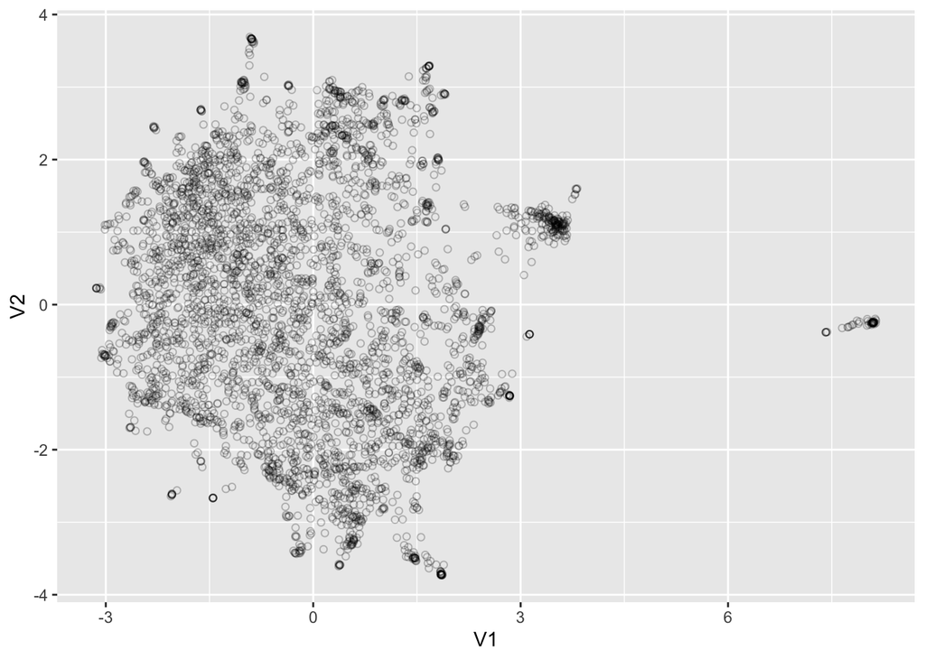

```r
sms_vectors_umap %>%
  ggplot(aes(x = V1, y = V2)) +
  geom_point(shape = 21, alpha = 0.25)
```

# 5 Supervised

## 5.1 GLM

```r
set.seed(48743)
cv.folds <- createMultiFolds(train$ham_spam, k = 10, times = 1)

cv.cntrl <- trainControl(method = "repeatedcv", number = 10,
                         repeats = 1, index = cv.folds)
```

After making a dimensionality reduction with a corresponding train and test set, it is now time to construct models to predict whether a message is “ham” or “spam”. The models will use the value of each word from the dimensionality reduction matrix to determine if a message is spam or not. The first model that will be constructed is a Generalized Linear Model, where the prediction is modeled as a weighted sum of the features. We construct the model below:

```r
glm <- train(Label ~ ., data = train_svd, method = "glm",
                trControl = cv.cntrl, tuneLength = 7,family=binomial())
```

After constructing the GLM model, it is time to test the model on the actual test dataset which we created earlier.

```r
pred = predict(glm,test_svd)
```

We continue to present the results in an actual confusion matrix to make it more presentable.

```r
conf= table(test$ham_spam, pred)
```

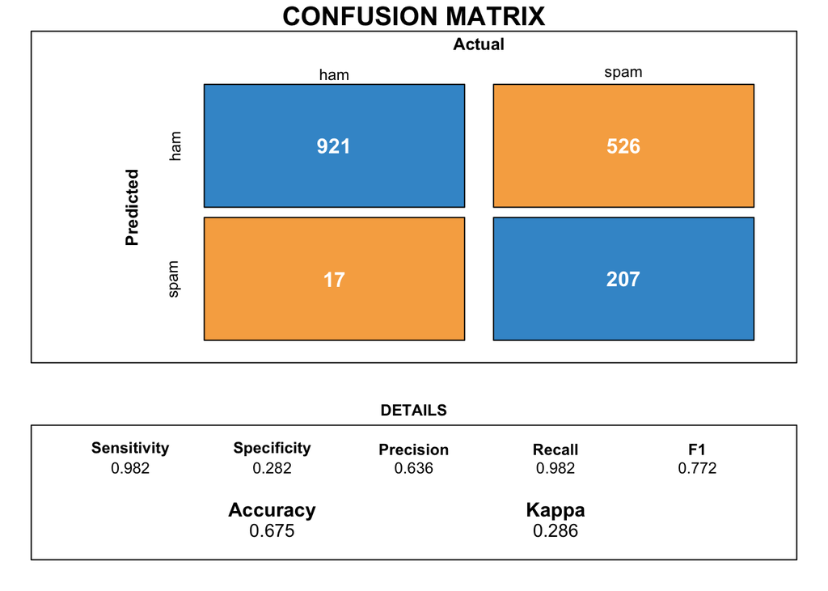

```r
cm = confusionMatrix(conf)
draw_confusion_matrix <- function(cm) {

  total <- sum(cm$table)
  res <- as.numeric(cm$table)

  layout(matrix(c(1,1,2)))
  par(mar=c(2,2,2,2))
  plot(c(100, 345), c(300, 450), type = "n", xlab="", ylab="", xaxt='n', yaxt='n')
  title('CONFUSION MATRIX', cex.main=2)

  # create the matrix
  classes = colnames(cm$table)
  rect(150, 430, 240, 370, col='#3F97D0')
  text(195, 435, 'ham', cex=1.2)
  rect(250, 430, 340, 370, col='#F7AD50')
  text(295, 435, 'spam', cex=1.2)
  text(125, 370, 'Predicted', cex=1.3, srt=90, font=2)
  text(245, 450, 'Actual', cex=1.3, font=2)
  rect(150, 305, 240, 365, col='#F7AD50')
  rect(250, 305, 340, 365, col='#3F97D0')
  text(140, 400, 'ham', cex=1.2, srt=90)
  text(140, 335, 'spam', cex=1.2, srt=90)

  # add in the cm results
  res <- as.numeric(cm$table)
  text(195, 400, res[1], cex=1.6, font=2, col='white')
  text(195, 335, res[2], cex=1.6, font=2, col='white')
  text(295, 400, res[3], cex=1.6, font=2, col='white')
  text(295, 335, res[4], cex=1.6, font=2, col='white')

  # add in the specifics
  plot(c(100, 0), c(100, 0), type = "n", xlab="", ylab="", main = "DETAILS", xaxt='n', yaxt='n')
  text(10, 85, names(cm$byClass[1]), cex=1.2, font=2)
  text(10, 70, round(as.numeric(cm$byClass[1]), 3), cex=1.2)
  text(30, 85, names(cm$byClass[2]), cex=1.2, font=2)
  text(30, 70, round(as.numeric(cm$byClass[2]), 3), cex=1.2)
  text(50, 85, names(cm$byClass[5]), cex=1.2, font=2)
  text(50, 70, round(as.numeric(cm$byClass[5]), 3), cex=1.2)
  text(70, 85, names(cm$byClass[6]), cex=1.2, font=2)
  text(70, 70, round(as.numeric(cm$byClass[6]), 3), cex=1.2)
  text(90, 85, names(cm$byClass[7]), cex=1.2, font=2)
  text(90, 70, round(as.numeric(cm$byClass[7]), 3), cex=1.2)

  # add in the accuracy information
  text(30, 35, names(cm$overall[1]), cex=1.5, font=2)
  text(30, 20, round(as.numeric(cm$overall[1]), 3), cex=1.4)
  text(70, 35, names(cm$overall[2]), cex=1.5, font=2)
  text(70, 20, round(as.numeric(cm$overall[2]), 3), cex=1.4)
}
draw_confusion_matrix(cm)
```

## 5.2 Decision tree

```r
DT <- train(Label ~ ., data = train_svd, method = "rpart",
                    trControl = cv.cntrl, tuneLength = 7)
```

After construction the model we test it on the same test dataset and present the results.

```r
pred2 = predict(DT, test_svd)
```

```r
conf2= table(test$ham_spam, pred2)
```

```r
cm = confusionMatrix(conf2)
```

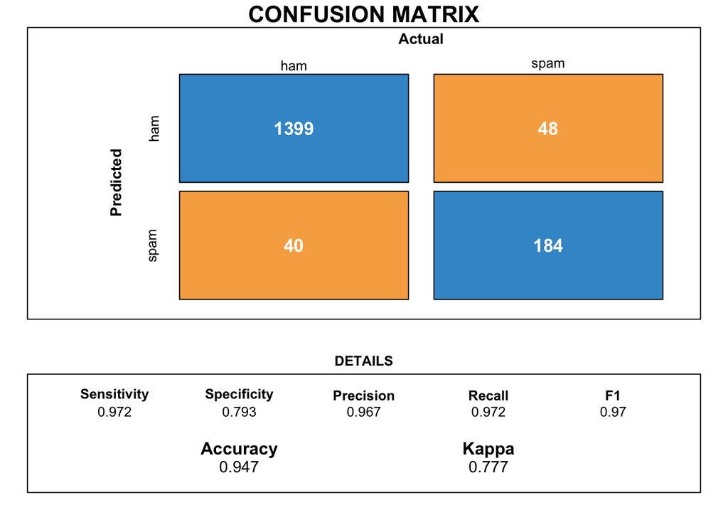

```r
draw_confusion_matrix <- function(cm) {

  total <- sum(cm$table)
  res <- as.numeric(cm$table)

  layout(matrix(c(1,1,2)))
  par(mar=c(2,2,2,2))
  plot(c(100, 345), c(300, 450), type = "n", xlab="", ylab="", xaxt='n', yaxt='n')
  title('CONFUSION MATRIX', cex.main=2)

  # create the matrix
  classes = colnames(cm$table)
  rect(150, 430, 240, 370, col='#3F97D0')
  text(195, 435, 'ham', cex=1.2)
  rect(250, 430, 340, 370, col='#F7AD50')
  text(295, 435, 'spam', cex=1.2)
  text(125, 370, 'Predicted', cex=1.3, srt=90, font=2)
  text(245, 450, 'Actual', cex=1.3, font=2)
  rect(150, 305, 240, 365, col='#F7AD50')
  rect(250, 305, 340, 365, col='#3F97D0')
  text(140, 400, 'ham', cex=1.2, srt=90)
  text(140, 335, 'spam', cex=1.2, srt=90)

  # add in the cm results
  res <- as.numeric(cm$table)
  text(195, 400, res[1], cex=1.6, font=2, col='white')
  text(195, 335, res[2], cex=1.6, font=2, col='white')
  text(295, 400, res[3], cex=1.6, font=2, col='white')
  text(295, 335, res[4], cex=1.6, font=2, col='white')

  # add in the specifics
  plot(c(100, 0), c(100, 0), type = "n", xlab="", ylab="", main = "DETAILS", xaxt='n', yaxt='n')
  text(10, 85, names(cm$byClass[1]), cex=1.2, font=2)
  text(10, 70, round(as.numeric(cm$byClass[1]), 3), cex=1.2)
  text(30, 85, names(cm$byClass[2]), cex=1.2, font=2)
  text(30, 70, round(as.numeric(cm$byClass[2]), 3), cex=1.2)
  text(50, 85, names(cm$byClass[5]), cex=1.2, font=2)
  text(50, 70, round(as.numeric(cm$byClass[5]), 3), cex=1.2)
  text(70, 85, names(cm$byClass[6]), cex=1.2, font=2)
  text(70, 70, round(as.numeric(cm$byClass[6]), 3), cex=1.2)
  text(90, 85, names(cm$byClass[7]), cex=1.2, font=2)
  text(90, 70, round(as.numeric(cm$byClass[7]), 3), cex=1.2)

  # add in the accuracy information
  text(30, 35, names(cm$overall[1]), cex=1.5, font=2)
  text(30, 20, round(as.numeric(cm$overall[1]), 3), cex=1.4)
  text(70, 35, names(cm$overall[2]), cex=1.5, font=2)
  text(70, 20, round(as.numeric(cm$overall[2]), 3), cex=1.4)
}
draw_confusion_matrix(cm)
```

## 5.3 Random forrest

```r
RF <- train(Label ~ ., data = train_svd, method = "rf",
                trControl = cv.cntrl, tuneLength = 7, ntree=25)
```

```r
pred3 = predict(RF,test_svd)
```

```r
conf3= table(test$ham_spam, pred3)
```

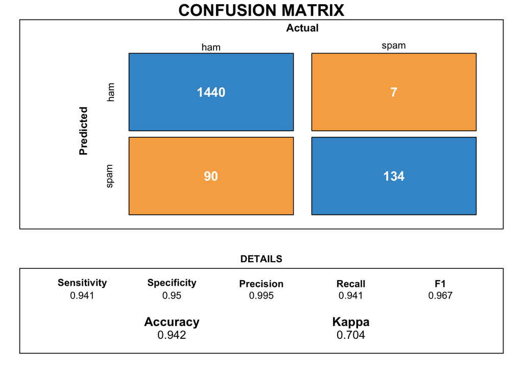

```r
cm = confusionMatrix(conf3)
draw_confusion_matrix <- function(cm) {

  total <- sum(cm$table)
  res <- as.numeric(cm$table)

  layout(matrix(c(1,1,2)))
  par(mar=c(2,2,2,2))
  plot(c(100, 345), c(300, 450), type = "n", xlab="", ylab="", xaxt='n', yaxt='n')
  title('CONFUSION MATRIX', cex.main=2)

  # create the matrix
  classes = colnames(cm$table)
  rect(150, 430, 240, 370, col='#3F97D0')
  text(195, 435, 'ham', cex=1.2)
  rect(250, 430, 340, 370, col='#F7AD50')
  text(295, 435, 'spam', cex=1.2)
  text(125, 370, 'Predicted', cex=1.3, srt=90, font=2)
  text(245, 450, 'Actual', cex=1.3, font=2)
  rect(150, 305, 240, 365, col='#F7AD50')
  rect(250, 305, 340, 365, col='#3F97D0')
  text(140, 400, 'ham', cex=1.2, srt=90)
  text(140, 335, 'spam', cex=1.2, srt=90)

  # add in the cm results
  res <- as.numeric(cm$table)
  text(195, 400, res[1], cex=1.6, font=2, col='white')
  text(195, 335, res[2], cex=1.6, font=2, col='white')
  text(295, 400, res[3], cex=1.6, font=2, col='white')
  text(295, 335, res[4], cex=1.6, font=2, col='white')

  # add in the specifics
  plot(c(100, 0), c(100, 0), type = "n", xlab="", ylab="", main = "DETAILS", xaxt='n', yaxt='n')
  text(10, 85, names(cm$byClass[1]), cex=1.2, font=2)
  text(10, 70, round(as.numeric(cm$byClass[1]), 3), cex=1.2)
  text(30, 85, names(cm$byClass[2]), cex=1.2, font=2)
  text(30, 70, round(as.numeric(cm$byClass[2]), 3), cex=1.2)
  text(50, 85, names(cm$byClass[5]), cex=1.2, font=2)
  text(50, 70, round(as.numeric(cm$byClass[5]), 3), cex=1.2)
  text(70, 85, names(cm$byClass[6]), cex=1.2, font=2)
  text(70, 70, round(as.numeric(cm$byClass[6]), 3), cex=1.2)
  text(90, 85, names(cm$byClass[7]), cex=1.2, font=2)
  text(90, 70, round(as.numeric(cm$byClass[7]), 3), cex=1.2)

  # add in the accuracy information
  text(30, 35, names(cm$overall[1]), cex=1.5, font=2)
  text(30, 20, round(as.numeric(cm$overall[1]), 3), cex=1.4)
  text(70, 35, names(cm$overall[2]), cex=1.5, font=2)
  text(70, 20, round(as.numeric(cm$overall[2]), 3), cex=1.4)
}
draw_confusion_matrix(cm)
```

# 6 Conclusion

We set out with a goal of making a spam filter that is able to tell if an SMS is spam or ham, to do this we started out by preparing our data by tokenizing and reducing the dimensionality of our data removing stop words and stemming. We then make an LDA topic detection stating that we want 2 topics, here we find 2 groups of words that seems to be divided in a way that ham and spam messages could be represented by each of the topics.